# Data Wrangling in R - Data Wrangling - 4

One should look for what is and not what he thinks should be. (Albert Einstein)

# Module completion checklist

| Objective | Complete |
| --- | --- |
| Select specific variables using the select command |  |
| Derive new variables from the existing variables using the mutate and transmute commands |  |

# Select

- `select()` helps you select specific columns within your dataframe

```r
# Check for detailed documentation
?dplyr::select

# Use cases for `select` function
select(df,           #<- dataframe
       select_cond1, #<- selection rule(s)
       ...)
```

- We often use this function with pipes(`%>%`) which we will cover later in the course
- The selection criteria can be written in multiple ways, as shown in the next couple of slides

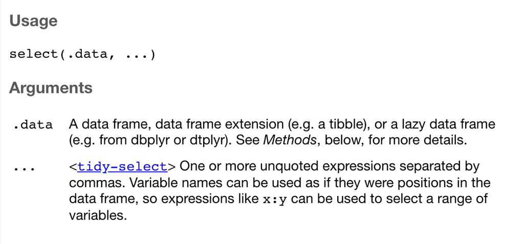

# Select a subset

- Simply specify the column name(s)

```r
# Select columns from `flights` data frame.
select(flights, #<- specify the data frame
       year,    #<- specify the 1st column
       month,   #<- specify the 2nd column
       day)     #<- specify the 3rd column
```

```
# A tibble: 336,776 x 3
    year month   day
   <int> <int> <int>
 1  2013     1     1
 2  2013     1     1
 3  2013     1     1
 4  2013     1     1
 5  2013     1     1
 6  2013     1     1
 7  2013     1     1
 8  2013     1     1
 9  2013     1     1
10  2013     1     1
# … with 336,766 more rows
```

- You can also specify a range of columns with the range operator (i.e. `:`)

```r
# Select columns from `flights` data frame
select(flights,  #<- specify the data frame
       year:day) #<- specify the range of columns
```

```
# A tibble: 336,776 x 3
    year month   day
   <int> <int> <int>
 1  2013     1     1
 2  2013     1     1
 3  2013     1     1
 4  2013     1     1
 5  2013     1     1
 6  2013     1     1
 7  2013     1     1
 8  2013     1     1
 9  2013     1     1
10  2013     1     1
# … with 336,766 more rows
```

# Select by excluding

- Finally, you can select by excluding certain columns using the exclusion operator (i.e. `-`)

```r
# Select multiple columns from `flights` data frame by providing which columns to exclude in selection
select(flights,     #<- specify the data frame
       -(year:day)) #<- specify the range of columns to exclude
```

```
# A tibble: 336,776 x 16
   dep_time sched_dep_time dep_delay arr_time sched_arr_time arr_delay carrier
      <int>          <int>     <dbl>    <int>          <int>     <dbl> <chr>
 1      517            515         2      830            819        11 UA
 2      533            529         4      850            830        20 UA
 3      542            540         2      923            850        33 AA
 4      544            545        -1     1004           1022       -18 B6
 5      554            600        -6      812            837       -25 DL
 6      554            558        -4      740            728        12 UA
 7      555            600        -5      913            854        19 B6
 8      557            600        -3      709            723       -14 EV
 9      557            600        -3      838            846        -8 B6
10      558            600        -2      753            745         8 AA
# … with 336,766 more rows, and 9 more variables: flight <int>, tailnum <chr>,
#   origin <chr>, dest <chr>, air_time <dbl>, distance <dbl>, hour <dbl>,
#   minute <dbl>, time_hour <dttm>
```

# Select - helper functions

- Helpers are multiple functions you can use to select variables based on their names
- They act like regular expressions, but in a more simplified manner
- Here are some of the more commonly used helper functions:

| Helper Function | Use Case |
| --- | --- |
| `starts_with(“abc”)` | matches names that begin with “abc” |
| `ends_with(“xyz”)` | matches names that end with “xyz” |
| `contains(“ijk”)` | matches names that contain “ijk” |
| `num_range(“x”, 1:3)` | matches “x1”, “x2” and “x3” |

# Select: Helper functions example

- To select columns whose names start with ‘arr’:

```r
select(flights, starts_with("arr"))
```

```
# A tibble: 336,776 x 2
   arr_time arr_delay
      <int>     <dbl>
 1      830        11
 2      850        20
 3      923        33
 4     1004       -18
 5      812       -25
 6      740        12
 7      913        19
 8      709       -14
 9      838        -8
10      753         8
# … with 336,766 more rows
```

# Module completion checklist

| Objective | Complete |
| --- | --- |
| Select specific variables, sometimes using specific rules, using the select command | **✔** |
| Derive new variables from the existing variables using the mutate and transmute commands |  |

# Mutate

- `mutate()` is an essential function of dplyr
- It allows us to **create** new variables using the current data and **append** these variables to the existing dataframe

```r
?dplyr::mutate

mutate(df,       # <- dataframe
       new_col1, # <- rule(s) for the new column
       ...)
```

- **Note:** `mutate()` always adds columns to the end of the dataset, so make sure you are able to see the last columns

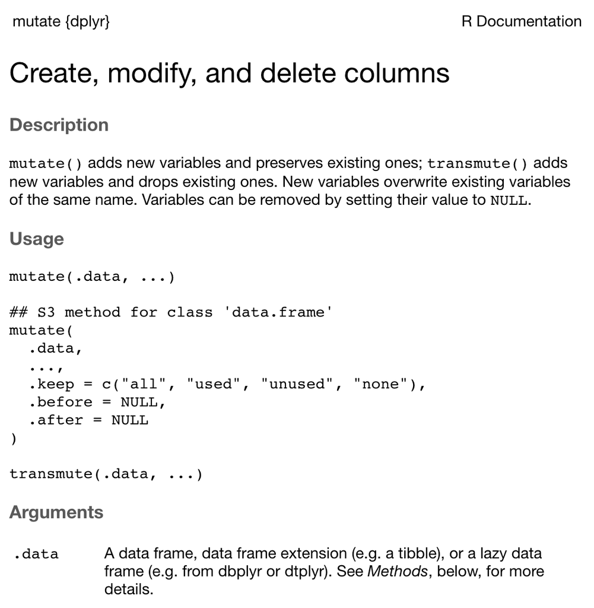

# First - create a new dataset

- Create the dataset using `select()`

```r
# Let's select columns of `flights` data frame and save them as `flights_sml`.
flights_sml = select(flights,            #<- specify data fra,e
                     year:day,           #<- specify range of columns to include
                     ends_with("delay"), #<- find all columns that end with `delay`
                     distance,           #<- select `distance` column
                     air_time)           #<- select `air_time` column
flights_sml
```

```
# A tibble: 336,776 x 7
    year month   day dep_delay arr_delay distance air_time
   <int> <int> <int>     <dbl>     <dbl>    <dbl>    <dbl>
 1  2013     1     1         2        11     1400      227
 2  2013     1     1         4        20     1416      227
 3  2013     1     1         2        33     1089      160
 4  2013     1     1        -1       -18     1576      183
 5  2013     1     1        -6       -25      762      116
 6  2013     1     1        -4        12      719      150
 7  2013     1     1        -5        19     1065      158
 8  2013     1     1        -3       -14      229       53
 9  2013     1     1        -3        -8      944      140
10  2013     1     1        -2         8      733      138
# … with 336,766 more rows
```

# Mutate - arguments

- The first argument is the dataframe
- The following arguments are the columns we would like to add to the data frame

```r
# Add two columns `gain` and `speed` to `flights_sml`.
mutate(flights_sml,                      #<- specify the data frame
       gain = arr_delay - dep_delay,     #<- create `gain` column by subtracting departure delay
                                         #   from arrival delay
       speed = distance / air_time * 60) #<- create `speed` from distance and air time columns
```

```
# A tibble: 336,776 x 9
    year month   day dep_delay arr_delay distance air_time  gain speed
   <int> <int> <int>     <dbl>     <dbl>    <dbl>    <dbl> <dbl> <dbl>
 1  2013     1     1         2        11     1400      227     9  370.
 2  2013     1     1         4        20     1416      227    16  374.
 3  2013     1     1         2        33     1089      160    31  408.
 4  2013     1     1        -1       -18     1576      183   -17  517.
 5  2013     1     1        -6       -25      762      116   -19  394.
 6  2013     1     1        -4        12      719      150    16  288.
 7  2013     1     1        -5        19     1065      158    24  404.
 8  2013     1     1        -3       -14      229       53   -11  259.
 9  2013     1     1        -3        -8      944      140    -5  405.
10  2013     1     1        -2         8      733      138    10  319.
# … with 336,766 more rows
```

# Transmute

- `transmute()` is a function that does the same thing as `mutate()` except it will only keep the new columns

```r
transmute(df,       # <- dataframe
          new_col1, # <- rule(s) for new column
          ...)
```

- The first argument is the dataframe
- The following arguments are the columns that will be included in your new data frame

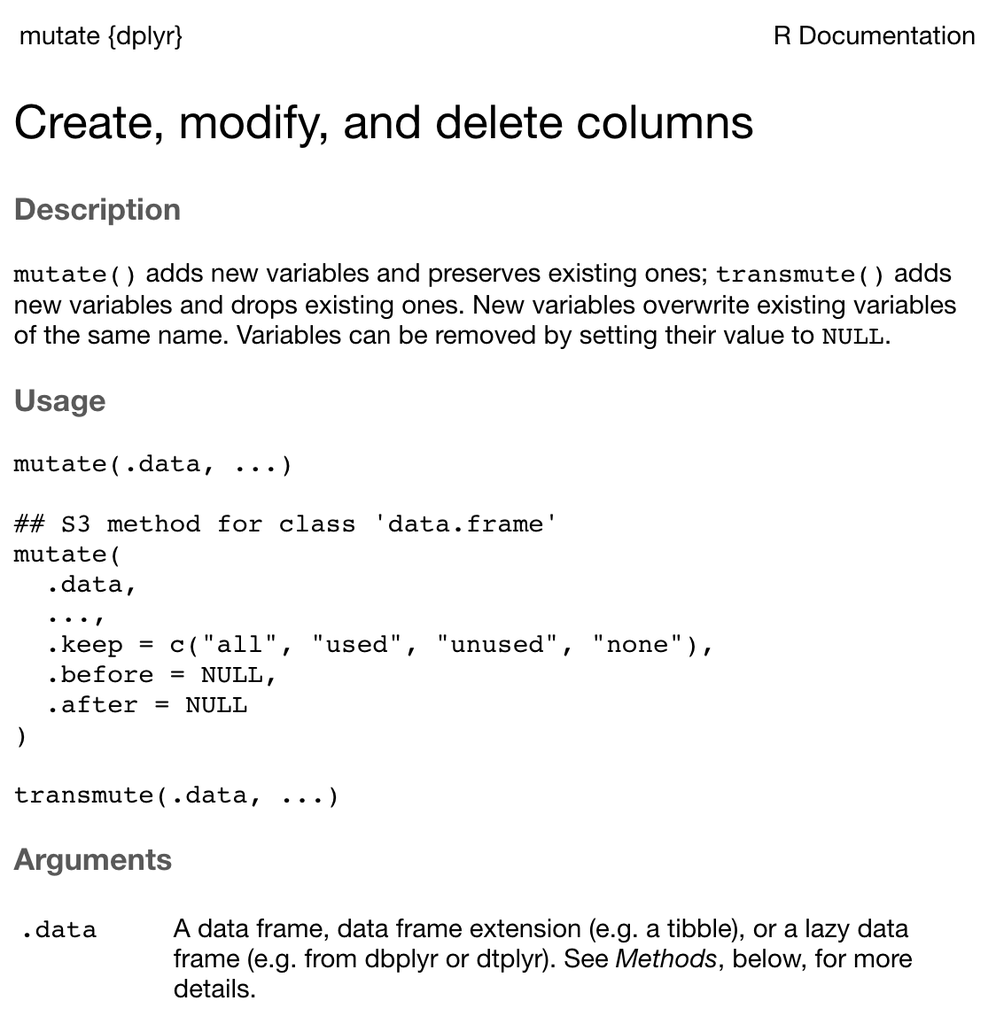

# Transmute example

- With the same arguments as in the `mutate()` example, we can see `transmute()` function only returns new columns

```r
# Add two columns `gain` and `speed` to `flights_sml`.
transmute(flights_sml,                      #<- specify the data frame
          gain = arr_delay - dep_delay,     #<- create `gain` column by subtracting departure delay
                                            #   from arrival delay
          speed = distance / air_time * 60) #<- create `speed` from distance and air time columns
```

```
# A tibble: 336,776 x 2
    gain speed
   <dbl> <dbl>
 1     9  370.
 2    16  374.
 3    31  408.
 4   -17  517.
 5   -19  394.
 6    16  288.
 7    24  404.
 8   -11  259.
 9    -5  405.
10    10  319.
# … with 336,766 more rows
```

# Mutate and transmute - useful functions

- When creating new variables with `mutate/transmute`, there are many helpful widgets and functions that can assist in creating interesting features:

| Useful Functions | Explanation |
| --- | --- |
| `+, -, *, /, ^` | all mathematical operators can be used on variables |
| `log, log2, log10` | logarithmic functions for variable transformation can be used |
| `%/%` and `%%` | modulus and remainder are useful when converting time |
| `lag(x)` and `lead(x)` | lag and lead allow reference to leading or lagging values - useful for detecting changes in values. |
| `cumsum(x)`,`cummean(x)`, `cummax(x)`,`cumprod(x)` | cumulative, running functions, mins, max, prod, mean, etc. |

# Mutate and transmute - useful functions (cont’d)

- Ranking functions are very helpful in data manipulation
- There are several within the `dplyr` package such as `row_number()`, `ntile()` and `dense_rank()`

```r
# Check for detailed documentation
rank_function(x) # <- one of rank functions with
                 #    a vector of values to rank
```

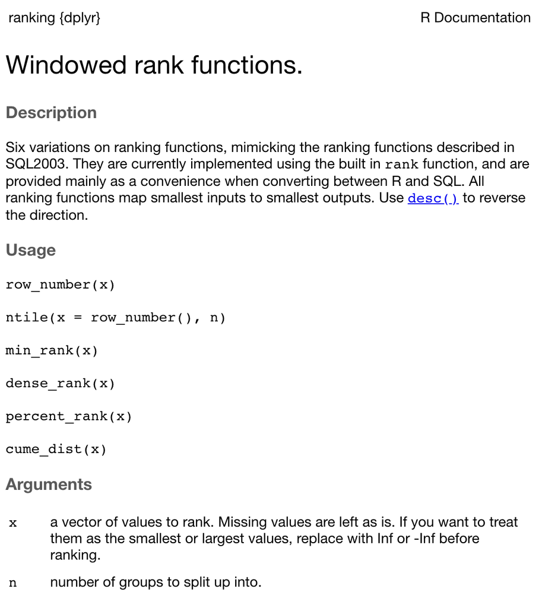

# Knowledge check

# Exercise

You are now ready to try Tasks 13-18 in the Exercise for this topic

# Module completion checklist

| Objective | Complete |
| --- | --- |
| Select specific variables, sometimes using specific rules, using the select command | **✔** |
| Derive new variables from the existing variables using the mutate and transmute commands | **✔** |

# Data Wrangling: Topic summary

In this part of the course, we have covered:

- Data wrangling basics
- Use dplyr for data wrangling

# Congratulations on completing this module!